# ISYE 6501

Homework 2

Artur Cabral, Marta Bras, Pedro Pinto, Katie Price

2019-09-05

# Question 3.1

*Using the same data set (credit_card_data.txt or credit_card_data-headers.txt) as in Question 2.2, use the ksvm or kknn function to find a good classifier:*

## 1. Cross-validation: kkn model

### Importing and preparing the data

```r
credit_card <- read.table("credit_card_data-headers.txt", sep= "", header = TRUE)
credit_card[,11]  <- factor(credit_card[,11])
```

### Choosing best model

The kknn package has a function - train kknn - that performs crossvalidation in 2 ways: 1) k-fold crossvalidation (cv.kknn) and 2) leave-one-out crossvalidation (train.kknn). The caret package also offers a train function to perform k-fold crossvalidation.

In the next steps, we perform the crossvalidation with the 3 functions, to understand which one and what number of neighbors provide the highest accuracy.

#### cv.kknn

cv.kkn uses k-fold crossvalidation: the dataset is split into a K number of sections/folds where each fold is used as a testing set at some point.

```r
# setting seed for reproducibility
set.seed(123)

# looping through different numbers of neighbors to find the perfect number using cv.kknn for crossvalidation
v_accuracy <- vector()

for (k in 1:30){
  pred <- c()
  knn <- cv.kknn(R1 ~ .,credit_card , k = k, kcv = 10,  scale=TRUE)
  pred <- c(pred, as.integer(knn[[1]][,2])-1) # rounding prediction to either one or zero
  accuracy <- sum(pred == credit_card[,11]) / nrow(credit_card)
  cat("\n For K = ", k, "accuracy = ", accuracy, "\n")
  v_accuracy <- c(v_accuracy,accuracy)
}
```

```
##
##  For K =  1 accuracy =  0.7981651
##
##  For K =  2 accuracy =  0.8119266
##
##  For K =  3 accuracy =  0.8027523
##
##  For K =  4 accuracy =  0.8088685
##
##  For K =  5 accuracy =  0.853211
##
##  For K =  6 accuracy =  0.851682
##
##  For K =  7 accuracy =  0.8501529
##
##  For K =  8 accuracy =  0.8409786
##
##  For K =  9 accuracy =  0.8501529
##
##  For K =  10 accuracy =  0.8409786
##
##  For K =  11 accuracy =  0.8486239
##
##  For K =  12 accuracy =  0.8394495
##
##  For K =  13 accuracy =  0.8394495
##
##  For K =  14 accuracy =  0.8486239
##
##  For K =  15 accuracy =  0.8501529
##
##  For K =  16 accuracy =  0.8409786
##
##  For K =  17 accuracy =  0.8562691
##
##  For K =  18 accuracy =  0.851682
##
##  For K =  19 accuracy =  0.8547401
##
##  For K =  20 accuracy =  0.8363914
##
##  For K =  21 accuracy =  0.8440367
##
##  For K =  22 accuracy =  0.8455657
##
##  For K =  23 accuracy =  0.8440367
##
##  For K =  24 accuracy =  0.8409786
##
##  For K =  25 accuracy =  0.8425076
##
##  For K =  26 accuracy =  0.8394495
##
##  For K =  27 accuracy =  0.8333333
##
##  For K =  28 accuracy =  0.8501529
##
##  For K =  29 accuracy =  0.8348624
##
##  For K =  30 accuracy =  0.8486239
```

```r
#best accuracy
cat("\n The best value of k is K = ", match(c(max(v_accuracy,na.rm = TRUE)),v_accuracy), " with accuracy = ", max(v_accuracy,na.rm = TRUE), "\n")
```

```
##
##  The best value of k is K =  17  with accuracy =  0.8562691
```

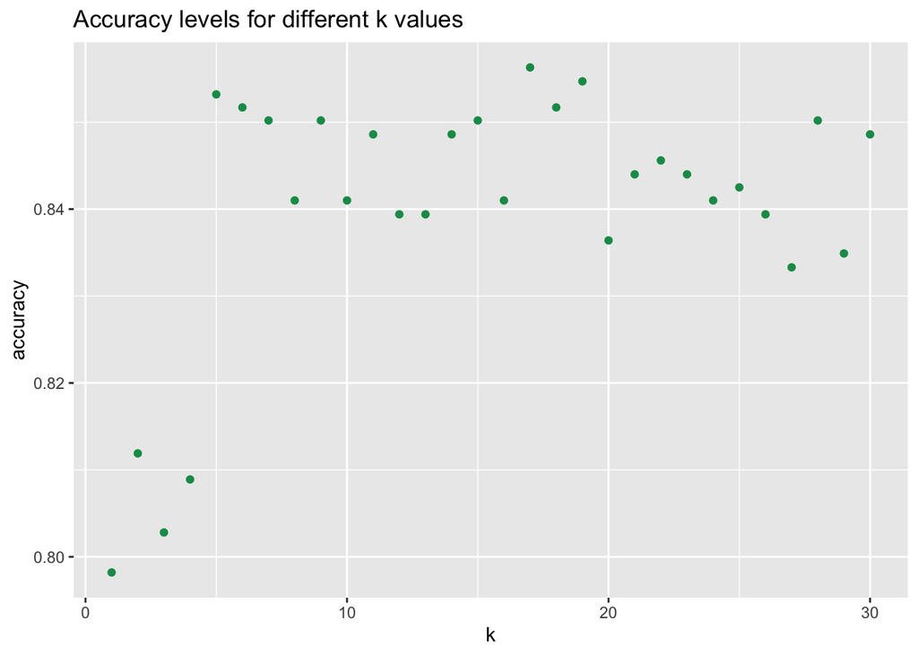

```r
#outputting the results
number <-  seq((1: length(v_accuracy)))
accuracy <- cbind(round(v_accuracy,4), number)
colnames(accuracy) <- c("accuracy","k")
accuracy <- as.data.frame(accuracy)

ggplot(accuracy, aes(x=k, y=accuracy)) +
  geom_point(color = "#159957") +
  ggtitle("Accuracy levels for different k values")
```

#### train.kknn

train.kkn uses leave-one-out crossvalidation - the data is trained on every point except one, for which the prediction is made.

```r
# setting seed for reproducibility
set.seed(123)

# Fitting model with multiple k values
model <- train.kknn(R1~.,credit_card,kmax=30,scale=TRUE)
best_parameter = as.integer(model$best.parameters[2]$k)
min_error = model$MISCLASS[best_parameter]
accuracy = (1 - min_error)


cat("\n The best value of k is K = ", best_parameter, " with accuracy = ",  accuracy)
```

```
##
##  The best value of k is K =  12  with accuracy =  0.853211
```

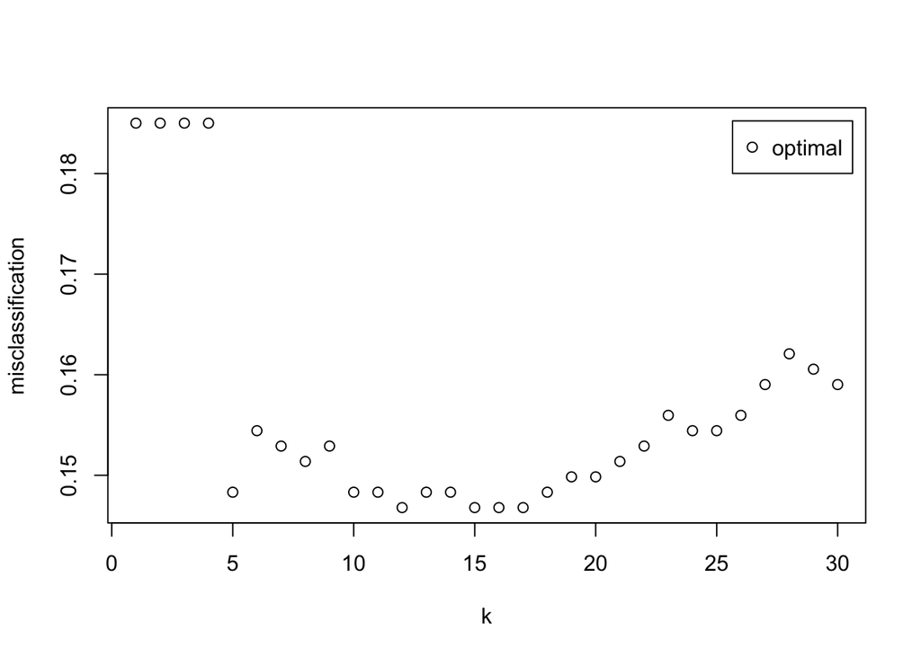

```r
#outputting the results
plot(model)
```

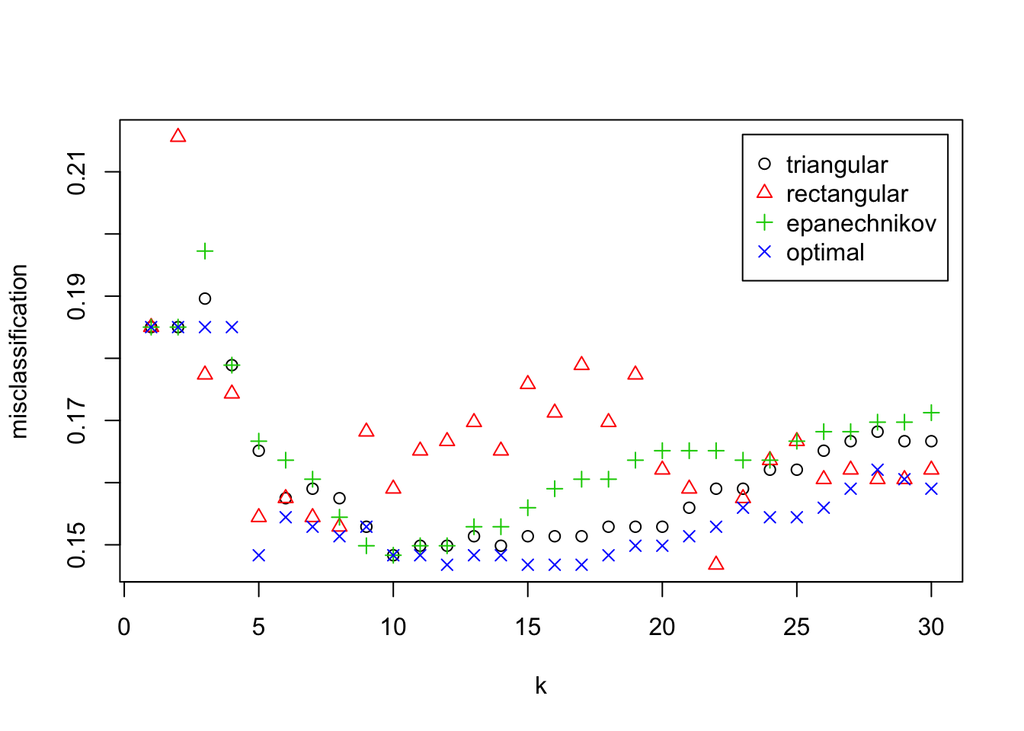

```r
#trying different kernells
model_2 <- train.kknn(R1~., credit_card, kmax = 30, kernel =
                        c("triangular", "rectangular", "epanechnikov", "optimal"), distance = 2)

plot(model_2)
```

#### train from caret package

We can also use the caret package which has the train function to perform k-fold crossvalidation.

```r
#setting seed for reproducibility
set.seed(123)

#creating the train control parameter wiht 10 folds and 5 repetitions
trControl <- trainControl(method  = "repeatedcv",
                          number  = 10,
                          repeats = 5)

#ftting the model with the defined train control
model <- train(R1 ~ A1 + A2 + A3 + A8 + A9 + A10 + A11 + A12 + A14 + A15,
               method     = "knn",
               trControl  = trControl,
               metric     = "Accuracy",
               data       = credit_card,
               preProcess = c("center", "scale"),
               tuneLength = 30)

#best parameters
index = which.max(model$results[,2])
accuracy = model$results[index,2]
k = model$results[index,1]

cat("\n The best value of k is K = ", k, " with accuracy = ",  accuracy)
```

```
##
##  The best value of k is K =  5  with accuracy =  0.8455686
```

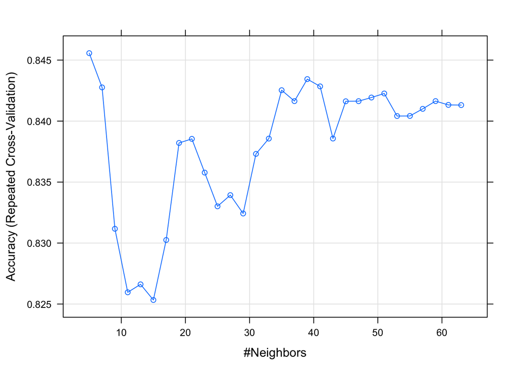

```r
#outputting the results
plot(model)
```

#### Conclusion

The best accuracy is obtained with the **17 neighbors** using **cv.kknn**.

## 2. Cross-validation: ksvm model

### k-fold Cross-Validation:

```r
#Performing k-fold cross-validation usign the tune function from the e1071 library:

#Preparing data

credit_card_svm <- data.matrix(credit_card)
class <- credit_card_svm[,11]
predictors <-  credit_card_svm[,1:10]

#creating dataframe
credit_card_2 <- data.frame(predictors =predictors, class)

# find optimal cost of misclassification
svmfit <- svm(class~., data = credit_card_2, kernel = "linear", cost = 10, gamma = 1)

tune.out <- tune(svm, class~., data = credit_card_2, kernel = "linear",
                 ranges = list(cost = c(0.001, 100,0.01, 0.1, 1, 5, 10, 100)))

# extract the best model
(bestmod <- tune.out$best.model)
```

```
##
## Call:
## best.tune(method = svm, train.x = class ~ ., data = credit_card_2,
##     ranges = list(cost = c(0.001, 100, 0.01, 0.1, 1, 5, 10, 100)),
##     kernel = "linear")
##
##
## Parameters:
##    SVM-Type:  eps-regression
##  SVM-Kernel:  linear
##        cost:  0.001
##       gamma:  0.1
##     epsilon:  0.1
##
##
## Number of Support Vectors:  562
```

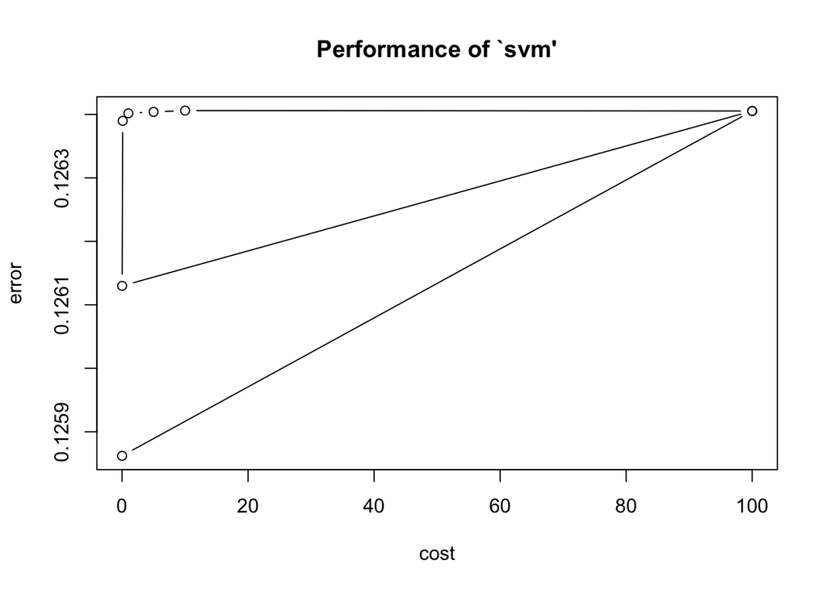

```r
#graph of error values for different C values

plot(tune.out)
```

### KSVM model and results

```r
best_model <- ksvm(predictors, class, kernel="vanilladot", type = "C-svc", C=0.01,scaled=TRUE)
#printing parameters
best_model
```

```
## Support Vector Machine object of class "ksvm"
##
## SV type: C-svc  (classification)
##  parameter : cost C = 0.01
##
## Linear (vanilla) kernel function.
##
## Number of Support Vectors : 288
##
## Objective Function Value : -2.2926
## Training error : 0.136086
```

```r
#predicting for dataset
ypred <- predict(best_model, predictors)

#plotting confusion matrix
misclass <- table(predict = ypred, truth = class)
misclass
```

```
##        truth
## predict   1   2
##       1 286  17
##       2  72 279
```

### Decision boundary function

```r
# calculate a1…am
a <- colSums(best_model@xmatrix[[1]] * best_model@coef[[1]])
a
```

```
##            A1            A2            A3            A8            A9
## -0.0001500738 -0.0014818294  0.0014083130  0.0072863886  0.9916470037
##           A10           A11           A12           A14           A15
## -0.0044661236  0.0071482899 -0.0005468386 -0.0016930578  0.1054824270
```

```r
# calculate a0
a0 <- best_model@b
a0
```

```
## [1] -0.08198854
```

The decision boundary function is:

*-0.08198854 + -0.0001500738A1 + -0.0014818294A2 + 0.0014083130A3 + 0.0072863886A8 + 0.9916470037A9 + -0.0044661236A10 + 0.0071482899A11 + -0.0005468386A2 + -0.0016930578A14 + 0.1054824270A15*

## 3. Training, validation, and testing: kknn

### Splitting data into training, validation and testing

```r
#setting seed for reproducibility
set.seed(123)

#setting 60% for training
ind <- sample(1:nrow(credit_card),floor(nrow(credit_card)*0.60))
credit_card_training <- credit_card[ind,]

#setting half of remaining for validation
credit_card_remaining <- credit_card[-ind,]
ind_2 <- sample(1:nrow(credit_card_remaining),floor(nrow(credit_card_remaining)*0.50))
credit_card_val <- credit_card_remaining[ind_2,]

#setting half of remaining for testing
credit_card_test <- credit_card_remaining[-ind_2,]
```

### Building the model and checking accuracy

```r
# looping through different numbers of neighbors to find the perfect number using kknn function

v_accuracy <- vector()

for (k in 1:30){
  pred <- c()
  knn <- kknn(R1 ~ .,credit_card_training,credit_card_val, k = k,  scale=TRUE)
  pred <- c(pred, as.integer(fitted(knn))-1) # rounding prediction to either one or zero
  #pred <- pred-1
  accuracy <- sum(pred == credit_card_val[,11]) / nrow(credit_card_val)
  cat("\n For K = ", k, "accuracy = ", accuracy, "\n")
  v_accuracy <- c(v_accuracy,accuracy)
}
```

```
##
##  For K =  1 accuracy =  0.8320611
##
##  For K =  2 accuracy =  0.8320611
##
##  For K =  3 accuracy =  0.8320611
##
##  For K =  4 accuracy =  0.8320611
##
##  For K =  5 accuracy =  0.8473282
##
##  For K =  6 accuracy =  0.8549618
##
##  For K =  7 accuracy =  0.8549618
##
##  For K =  8 accuracy =  0.8549618
##
##  For K =  9 accuracy =  0.8549618
##
##  For K =  10 accuracy =  0.8625954
##
##  For K =  11 accuracy =  0.870229
##
##  For K =  12 accuracy =  0.870229
##
##  For K =  13 accuracy =  0.870229
##
##  For K =  14 accuracy =  0.8778626
##
##  For K =  15 accuracy =  0.8854962
##
##  For K =  16 accuracy =  0.8854962
##
##  For K =  17 accuracy =  0.8854962
##
##  For K =  18 accuracy =  0.8854962
##
##  For K =  19 accuracy =  0.8931298
##
##  For K =  20 accuracy =  0.8931298
##
##  For K =  21 accuracy =  0.8931298
##
##  For K =  22 accuracy =  0.8931298
##
##  For K =  23 accuracy =  0.8931298
##
##  For K =  24 accuracy =  0.8854962
##
##  For K =  25 accuracy =  0.8854962
##
##  For K =  26 accuracy =  0.8854962
##
##  For K =  27 accuracy =  0.8778626
##
##  For K =  28 accuracy =  0.8778626
##
##  For K =  29 accuracy =  0.8778626
##
##  For K =  30 accuracy =  0.8778626
```

```r
#best accuracy in validation dataset

cat("\n The best value of k is K = ", match(c(max(v_accuracy,na.rm = TRUE)),v_accuracy), " with accuracy in validation dataset of = ", max(v_accuracy,na.rm = TRUE), "\n")
```

```
##
##  The best value of k is K =  19  with accuracy in validation dataset of =  0.8931298
```

### Checking accuracy on the testing dataset

```r
# fitting model with best k number
knn_test <- kknn(R1 ~.,credit_card_training,credit_card_test, k = match(c(max(v_accuracy,na.rm = TRUE)), v_accuracy), scale=TRUE)

#predict in test dataset
pred_test <- as.integer(fitted(knn_test))-1

#accuracy in testing dataset
accuracy_test <- sum(pred_test == credit_card_test[,11]) / nrow(credit_card_test)


cat("\n The performance of the model in the test dataset is: ", accuracy_test, "\n")
```

```
##
##  The performance of the model in the test dataset is:  0.8854962
```

# Question 4.1

*Describe a situation or problem from your job, everyday life, current events, etc., for which a clustering model would be appropriate. List some (up to 5) predictors that you might use.*

Clustering would be appropriate to study earth-quakes. Based on the areas hit by an earthquake in a region, clustering can help analyse the next probable location where the earthquake can occur.  
The predictors would be for example:

1. Past Events: previous earthquakes occurences in the same region, and its parameters
2. Changes in velocity of primary and secondary seismic waves
3. Random emissions
4. Electromagnetic anomalies

Identifying regions at-risk might help governments better alocate resources to these areas to develop better infrastructure and prevent catastrophic outcomes.

# Question 4.2

*Use the R function kmeans to cluster the points as well as possible. Report the best combination of predictors, your suggested value of k, and how well your best clustering predicts flower type.*

## Importing and brief EDA of the data

```r
#importing data
iris <- iris
classifiers <- iris[,1:4]
class <- iris[,5]
```

```r
#getting a glimpse of data
glimpse(iris)
```

```
## Observations: 150
## Variables: 5
## $ Sepal.Length <dbl> 5.1, 4.9, 4.7, 4.6, 5.0, 5.4, 4.6, 5.0, 4.4, 4.9, 5…
## $ Sepal.Width  <dbl> 3.5, 3.0, 3.2, 3.1, 3.6, 3.9, 3.4, 3.4, 2.9, 3.1, 3…
## $ Petal.Length <dbl> 1.4, 1.4, 1.3, 1.5, 1.4, 1.7, 1.4, 1.5, 1.4, 1.5, 1…
## $ Petal.Width  <dbl> 0.2, 0.2, 0.2, 0.2, 0.2, 0.4, 0.3, 0.2, 0.2, 0.1, 0…
## $ Species      <fct> setosa, setosa, setosa, setosa, setosa, setosa, set…
```

```r
#number of observations per plant type
dt <- iris %>% group_by(Species) %>%
  summarize(number_plants = length(Species)
  )

kable(dt, caption = "Number of observations per specie type") %>%
  kable_styling(bootstrap_options = c("striped", "hover", "condensed", "bordered"))
```

Number of observations per specie type

| Species | number_plants |
| --- | --- |
| setosa | 50 |
| versicolor | 50 |
| virginica | 50 |

```r
#main statistics for sepal length
dt <- iris %>% group_by(Species) %>%
  summarize(
    average = mean(Sepal.Length),
    max = max(Sepal.Length),
    min = min(Sepal.Length),
    var = round(var(Sepal.Length),2))

kable(dt, caption = "Main statistics for sepal length") %>%
  kable_styling(bootstrap_options = c("striped", "hover", "condensed", "bordered"))
```

Main statistics for sepal length

| Species | average | max | min | var |
| --- | --- | --- | --- | --- |
| setosa | 5.006 | 5.8 | 4.3 | 0.12 |
| versicolor | 5.936 | 7.0 | 4.9 | 0.27 |
| virginica | 6.588 | 7.9 | 4.9 | 0.40 |

```r
#main statistics for sepal width
dt <- iris %>% group_by(Species) %>%
  summarize(
    average = mean(Sepal.Width),
    max = max(Sepal.Width),
    min = min(Sepal.Width),
    var = round(var(Sepal.Width),2))

kable(dt, caption = "Main statistics for sepal width") %>%
  kable_styling(bootstrap_options = c("striped", "hover", "condensed", "bordered"))
```

Main statistics for sepal width

| Species | average | max | min | var |
| --- | --- | --- | --- | --- |
| setosa | 3.428 | 4.4 | 2.3 | 0.14 |
| versicolor | 2.770 | 3.4 | 2.0 | 0.10 |
| virginica | 2.974 | 3.8 | 2.2 | 0.10 |

```r
#main statistics for petal length
dt <- iris %>% group_by(Species) %>%
  summarize(
    average = mean(Petal.Length),
    max = max(Petal.Length),
    min = min(Petal.Length),
    var = round(var(Petal.Length),2))

kable(dt, caption = "Main statistics for petal length") %>%
  kable_styling(bootstrap_options = c("striped", "hover", "condensed", "bordered"))
```

Main statistics for petal length

| Species | average | max | min | var |
| --- | --- | --- | --- | --- |
| setosa | 1.462 | 1.9 | 1.0 | 0.03 |
| versicolor | 4.260 | 5.1 | 3.0 | 0.22 |
| virginica | 5.552 | 6.9 | 4.5 | 0.30 |

```r
#main statistics for petal width
dt <- iris %>% group_by(Species) %>%
  summarize(
    average = mean(Petal.Width),
    max = max(Petal.Width),
    min = min(Petal.Width),
    var = round(var(Petal.Width),2))

kable(dt, caption = "Main statistics for petal width") %>%
  kable_styling(bootstrap_options = c("striped", "hover", "condensed", "bordered"))
```

Main statistics for petal width

| Species | average | max | min | var |
| --- | --- | --- | --- | --- |
| setosa | 0.246 | 0.6 | 0.1 | 0.01 |
| versicolor | 1.326 | 1.8 | 1.0 | 0.04 |
| virginica | 2.026 | 2.5 | 1.4 | 0.08 |

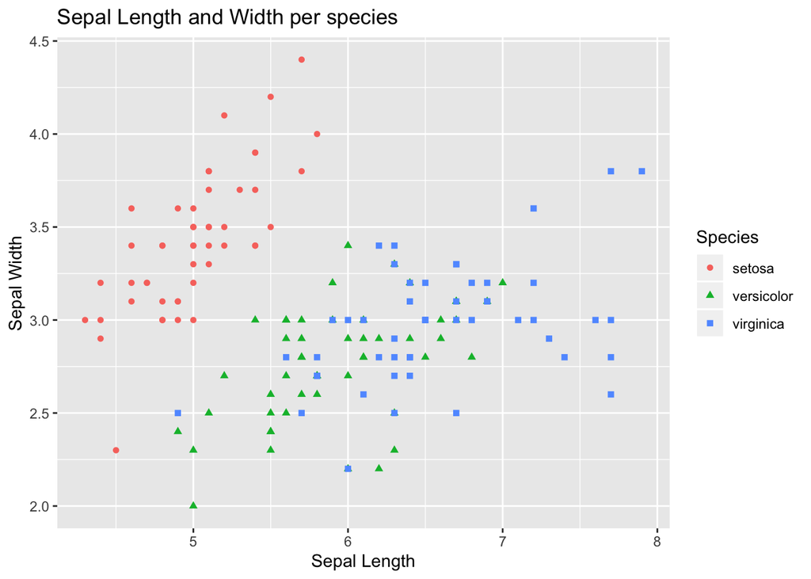

```r
#scatter plot 1
scatter <- ggplot(data=iris, aes(x = Sepal.Length, y = Sepal.Width))
scatter + geom_point(aes(color=Species, shape=Species)) +
  xlab("Sepal Length") +  ylab("Sepal Width") +
  ggtitle("Sepal Length and Width per species")
```

[figure not shown]

```r
#scatter plot 2
scatter <- ggplot(data=iris, aes(x = Sepal.Length, y = Sepal.Width))
scatter + geom_point(aes(color=Species, shape=Species)) +
  xlab("Petal Length") +  ylab("Petal Width") +
  ggtitle("Petal Length and Width per species")
```

## Finding optimal number of clusters

Because the starting assignments are random, we can specify nstart = 20. The algorithm will try 20 different random starting assignments and select the one that has a lowest within cluster variation.

For the value of k, we know 3 is a good starting point but we can try different values to check which one provides the best classification model.

We can also start by scaling the data, since that is a good practice for kmean.

```r
#scaling data
set.seed(123)

scale_data = matrix(nrow=nrow(classifiers), ncol=4)

for (i in (1 : length(classifiers))) {
  scale_data[,i] <- (classifiers[,i]-min(classifiers[,i]))/(max(classifiers)-min(classifiers[,i]))
}
```

```r
#trying different k values in the scaled data
k_max = 10
cluster = matrix(nrow=nrow(classifiers), ncol=k_max)
distance = matrix(nrow=k_max, ncol=length(classifiers))
total_withincluster = matrix(nrow=1, ncol=k_max)

for (i in (1 : k_max)) {
  models <- kmeans(scale_data[,1:4], i, nstart = 20)
  cluster[,i] <- models$cluster
  distance[i,] <- models$centers[models$cluster[i],]
  total_withincluster[,i] <- models$tot.withinss
}
```

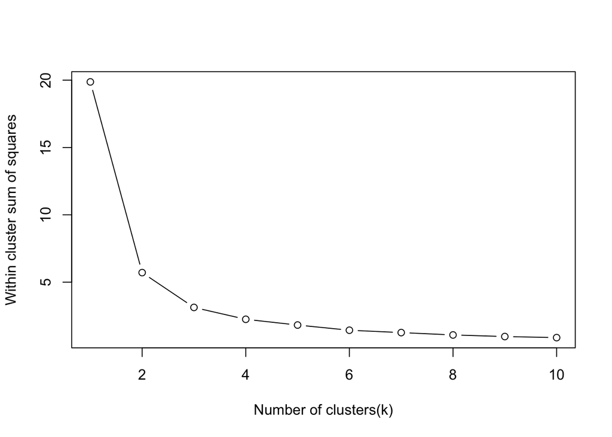

```r
#creating a Within Cluster plot
plot(1:k_max,total_withincluster, type= "b", xlab = "Number of clusters(k)", ylab = "Within cluster sum of squares")
```

Looking at the Within Cluster graph, there seems to be an elbow at k = 3. We can use k = 3 in the final cluster model.

## Building the model with 3 clusters for scaled data

```r
#model with k = 3
model <- kmeans(scale_data[,1:4], 3, nstart = 20)

model
```

```
## K-means clustering with 3 clusters of sizes 56, 44, 50
##
## Cluster means:
##        [,1]      [,2]       [,3]       [,4]
## 1 0.4181548 0.1213680 0.49120083 0.17124542
## 2 0.7064394 0.1814330 0.66139657 0.24125874
## 3 0.1961111 0.2420339 0.06695652 0.01871795
##
## Clustering vector:
##   [1] 3 3 3 3 3 3 3 3 3 3 3 3 3 3 3 3 3 3 3 3 3 3 3 3 3 3 3 3 3 3 3 3 3 3 3
##  [36] 3 3 3 3 3 3 3 3 3 3 3 3 3 3 3 2 1 2 1 2 1 1 1 2 1 1 1 1 1 1 2 1 1 1 1
##  [71] 1 1 1 1 1 2 2 2 1 1 1 1 1 1 1 1 2 1 1 1 1 1 1 1 1 1 1 1 1 1 2 1 2 2 2
## [106] 2 1 2 2 2 2 2 2 1 1 2 2 2 2 1 2 1 2 1 2 2 1 1 2 2 2 2 2 1 1 2 2 2 1 2
## [141] 2 2 1 2 2 2 1 2 2 1
##
## Within cluster sum of squares by cluster:
## [1] 1.2088588 1.2018545 0.7120167
##  (between_SS / total_SS =  84.3 %)
##
## Available components:
##
## [1] "cluster"      "centers"      "totss"        "withinss"
## [5] "tot.withinss" "betweenss"    "size"         "iter"
## [9] "ifault"
```

```r
#plotting the classifications for k = 3 with cluster vector
table(cluster[,3],class)
```

```
##    class
##     setosa versicolor virginica
##   1      0         41        15
##   2     50          0         0
##   3      0          9        35
```

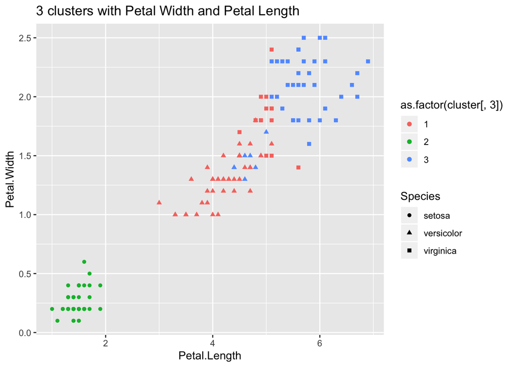

```r
#plotting clusters for petal length and petal width
ggplot(iris, aes(Petal.Length, Petal.Width, color = as.factor(cluster[,3]), shape=Species)) + geom_point() + ggtitle("3 clusters with Petal Width and Petal Length")
```

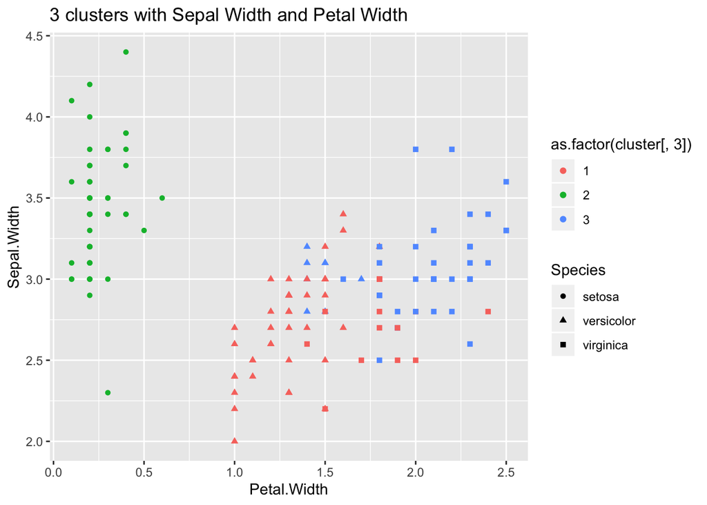

```r
#plotting clusters for sepal width and petal width
ggplot(iris, aes(Petal.Width, Sepal.Width, color = as.factor(cluster[,3]), shape=Species)) + geom_point() + ggtitle("3 clusters with Sepal Width and Petal Width")
```

## Building the model with 4 clusters for scaled data

We can also see how the model with 4 clusters performed and how the model with 3 clusters performed in the variable before being centered.

```r
table(cluster[,4],class)
```

```
##    class
##     setosa versicolor virginica
##   1      0          0        14
##   2      0         23        33
##   3     50          0         0
##   4      0         27         3
```

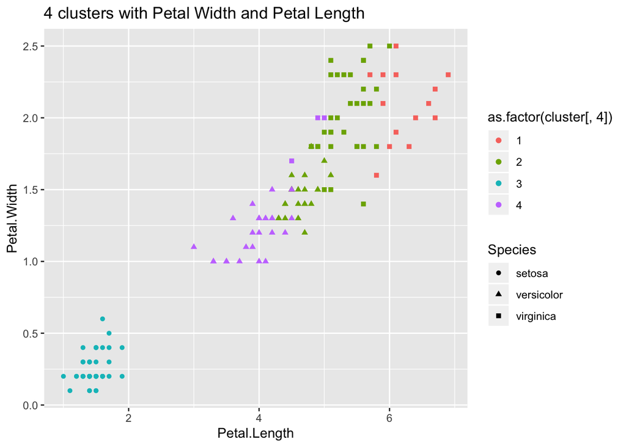

```r
#plotting clusters for petal length and petal width
ggplot(iris, aes(Petal.Length, Petal.Width, color = as.factor(cluster[,4]), shape=Species)) + geom_point() + ggtitle("4 clusters with Petal Width and Petal Length")
```

## Trying with original data

```r
#not scaled data k = 3
model <- kmeans(iris[,1:4], 3, nstart = 20)
model
```

```
## K-means clustering with 3 clusters of sizes 38, 50, 62
##
## Cluster means:
##   Sepal.Length Sepal.Width Petal.Length Petal.Width
## 1     6.850000    3.073684     5.742105    2.071053
## 2     5.006000    3.428000     1.462000    0.246000
## 3     5.901613    2.748387     4.393548    1.433871
##
## Clustering vector:
##   [1] 2 2 2 2 2 2 2 2 2 2 2 2 2 2 2 2 2 2 2 2 2 2 2 2 2 2 2 2 2 2 2 2 2 2 2
##  [36] 2 2 2 2 2 2 2 2 2 2 2 2 2 2 2 3 3 1 3 3 3 3 3 3 3 3 3 3 3 3 3 3 3 3 3
##  [71] 3 3 3 3 3 3 3 1 3 3 3 3 3 3 3 3 3 3 3 3 3 3 3 3 3 3 3 3 3 3 1 3 1 1 1
## [106] 1 3 1 1 1 1 1 1 3 3 1 1 1 1 3 1 3 1 3 1 1 3 3 1 1 1 1 1 3 1 1 1 1 3 1
## [141] 1 1 3 1 1 1 3 1 1 3
##
## Within cluster sum of squares by cluster:
## [1] 23.87947 15.15100 39.82097
##  (between_SS / total_SS =  88.4 %)
##
## Available components:
##
## [1] "cluster"      "centers"      "totss"        "withinss"
## [5] "tot.withinss" "betweenss"    "size"         "iter"
## [9] "ifault"
```

```r
#not scaled data k = 3
model <- kmeans(iris[,1:4], 4, nstart = 20)
model
```

```
## K-means clustering with 4 clusters of sizes 40, 28, 32, 50
##
## Cluster means:
##   Sepal.Length Sepal.Width Petal.Length Petal.Width
## 1     6.252500    2.855000     4.815000    1.625000
## 2     5.532143    2.635714     3.960714    1.228571
## 3     6.912500    3.100000     5.846875    2.131250
## 4     5.006000    3.428000     1.462000    0.246000
##
## Clustering vector:
##   [1] 4 4 4 4 4 4 4 4 4 4 4 4 4 4 4 4 4 4 4 4 4 4 4 4 4 4 4 4 4 4 4 4 4 4 4
##  [36] 4 4 4 4 4 4 4 4 4 4 4 4 4 4 4 1 1 1 2 1 2 1 2 1 2 2 2 2 1 2 1 2 2 1 2
##  [71] 1 2 1 1 1 1 1 1 1 2 2 2 2 1 2 1 1 1 2 2 2 1 2 2 2 2 2 1 2 2 3 1 3 3 3
## [106] 3 2 3 3 3 1 1 3 1 1 3 3 3 3 1 3 1 3 1 3 3 1 1 3 3 3 3 3 1 1 3 3 3 1 3
## [141] 3 3 1 3 3 3 1 1 3 1
##
## Within cluster sum of squares by cluster:
## [1] 13.624750  9.749286 18.703437 15.151000
##  (between_SS / total_SS =  91.6 %)
##
## Available components:
##
## [1] "cluster"      "centers"      "totss"        "withinss"
## [5] "tot.withinss" "betweenss"    "size"         "iter"
## [9] "ifault"
```